# Изучение закономерностей, определяющих успешность игр

### 3.6. Влияние отзывов экспертов на продажи

К плану работ

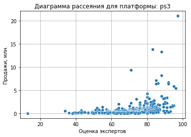

```
Коэффициент корреляции Пирсона между суммой продаж и отзывами экспертов для платформы ps3 : 0.38219181212263775
```

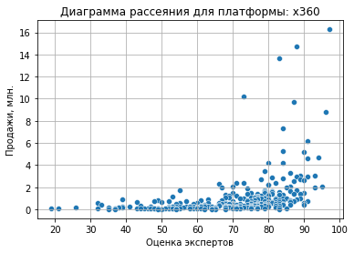

```
Коэффициент корреляции Пирсона между суммой продаж и отзывами экспертов для платформы x360 : 0.39019510962910064
```

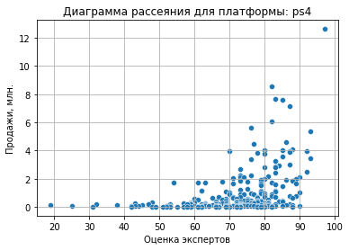

```
Коэффициент корреляции Пирсона между суммой продаж и отзывами экспертов для платформы ps4 : 0.406567902061781
```

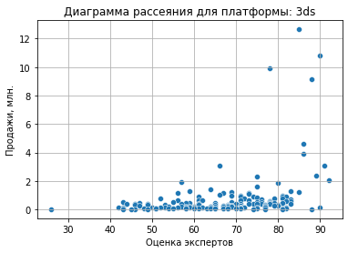

```
Коэффициент корреляции Пирсона между суммой продаж и отзывами экспертов для платформы 3ds : 0.34821555174929825
```

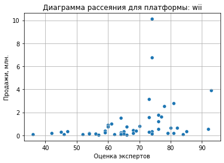

```
Коэффициент корреляции Пирсона между суммой продаж и отзывами экспертов для платформы wii : 0.29879465491775925
```

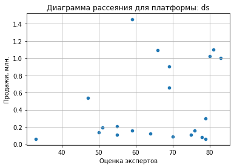

```
Коэффициент корреляции Пирсона между суммой продаж и отзывами экспертов для платформы ds : 0.26528596510868785
```

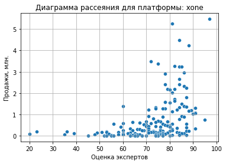

```
Коэффициент корреляции Пирсона между суммой продаж и отзывами экспертов для платформы xone : 0.41699832800840175
```

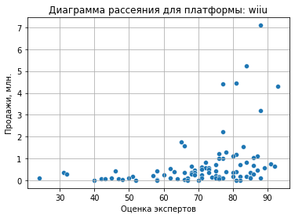

```
Коэффициент корреляции Пирсона между суммой продаж и отзывами экспертов для платформы wiiu : 0.3483797601201749
```

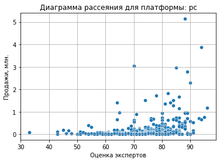

```
Коэффициент корреляции Пирсона между суммой продаж и отзывами экспертов для платформы pc : 0.3167333790665373
```

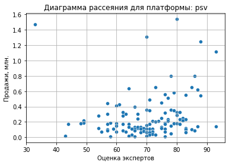

```
Коэффициент корреляции Пирсона между суммой продаж и отзывами экспертов для платформы psv : 0.13176292727608935
```

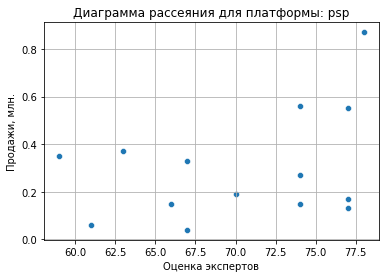

```
Коэффициент корреляции Пирсона между суммой продаж и отзывами экспертов для платформы psp : 0.3581381002722692
```

[figure not shown]

```
Коэффициент корреляции Пирсона между суммой продаж и отзывами экспертов для платформы ps2 : nan
```

```python
# создаем цикл и перебирая платформы строим диаграммы рассеяния для каждой из платформ
for elem in data_actual_period['platform'].unique():
    data_tmp = data_actual_period[data_actual_period['platform'] == elem]

    fig, ax = plt.subplots()
    sns.scatterplot(data=data_tmp, x='critic_score', y='total_sales', ax=ax)
    ax.set_title('Диаграмма рассеяния для платформы: '+elem)
    plt.xlabel('Оценка экспертов')
    plt.ylabel('Продажи, млн.')
    plt.grid()
    plt.show()
# выводим значение коэффициента корреляции Пирсона
    print('Коэффициент корреляции Пирсона между суммой продаж и отзывами экспертов для платформы', elem, ':',
              data_tmp['total_sales'].corr(data_tmp['critic_score']))
```

### 3.7. Влияние отзывов пользователей на продажи

К плану работ

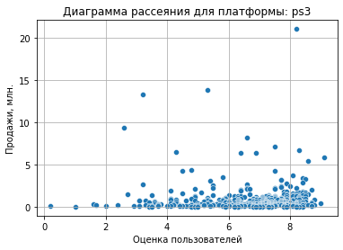

```
Коэффициент корреляции Пирсона между суммой продаж и отзывами пользователей для платформы ps3 : 0.013161511421637144
```

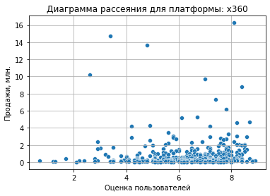

```
Коэффициент корреляции Пирсона между суммой продаж и отзывами пользователей для платформы x360 : 0.03904099609784627
```

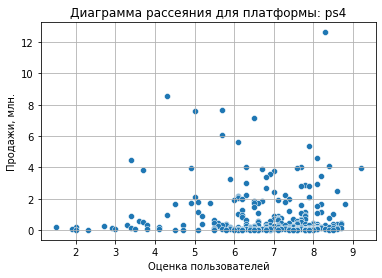

```
Коэффициент корреляции Пирсона между суммой продаж и отзывами пользователей для платформы ps4 : -0.031957110204556376
```

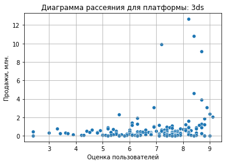

```
Коэффициент корреляции Пирсона между суммой продаж и отзывами пользователей для платформы 3ds : 0.22230511788401197
```

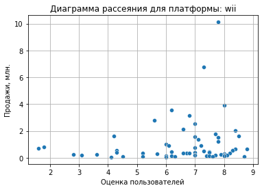

```
Коэффициент корреляции Пирсона между суммой продаж и отзывами пользователей для платформы wii : 0.14902915629464072
```

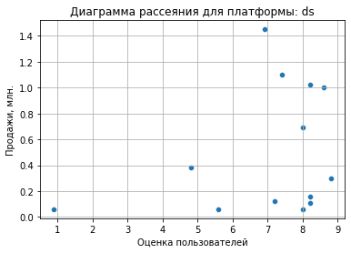

```
Коэффициент корреляции Пирсона между суммой продаж и отзывами пользователей для платформы ds : 0.2810294019560495
```

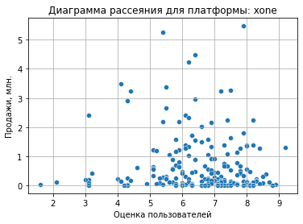

```
Коэффициент корреляции Пирсона между суммой продаж и отзывами пользователей для платформы xone : -0.06892505328279412
```

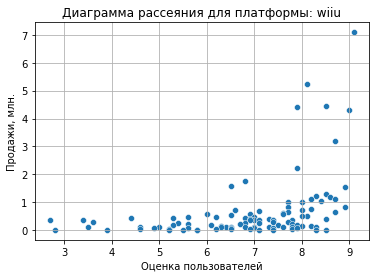

```
Коэффициент корреляции Пирсона между суммой продаж и отзывами пользователей для платформы wiiu : 0.4002190202148617
```

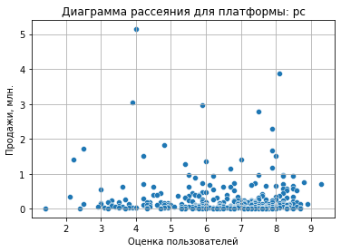

```
Коэффициент корреляции Пирсона между суммой продаж и отзывами пользователей для платформы pc : -0.04748880936415868
```

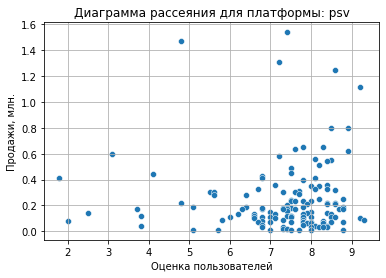

```
Коэффициент корреляции Пирсона между суммой продаж и отзывами пользователей для платформы psv : 0.013488756835886498
```

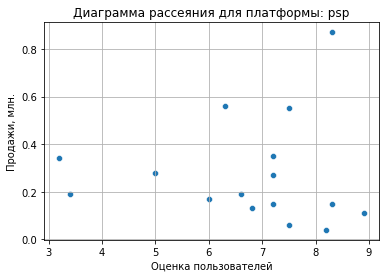

```
Коэффициент корреляции Пирсона между суммой продаж и отзывами пользователей для платформы psp : 0.010035480754033762
```

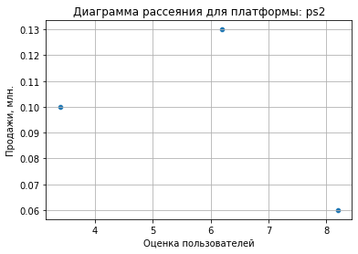

```
Коэффициент корреляции Пирсона между суммой продаж и отзывами пользователей для платформы ps2 : -0.48814358104490957
```

```python
for elem in data_actual_period['platform'].unique():
    data_tmp = data_actual_period[data_actual_period['platform'] == elem]
    plt.show()
    data_tmp = data_tmp[data_tmp['user_score'] != -1]# убираем все значения -1, которые мы заменили
    fig, ax = plt.subplots()
    sns.scatterplot(data=data_tmp, x='user_score', y='total_sales', ax=ax)
    ax.set_title('Диаграмма рассеяния для платформы: '+elem)
    plt.xlabel('Оценка пользователей')
    plt.ylabel('Продажи, млн.')
    plt.grid()
    plt.show()

    print('Коэффициент корреляции Пирсона между суммой продаж и отзывами пользователей для платформы', elem, ':',
              data_tmp['total_sales'].corr(data_tmp['user_score']))
```

```python
print('\nКоэффициент корреляции Пирсона между суммой продаж и отзывами экспертов по всем платформам:',
      data_actual_period['total_sales'].corr(data_actual_period['critic_score']))
data_actual_period1 = data_actual_period[data_actual_period['user_score'] != -1]
print('Коэффициент корреляции Пирсона между суммой продаж и отзывами пользователей по всем платформам:',
      data_actual_period1['total_sales'].corr(data_actual_period1['user_score']))
data_actual_period.head()
```

```
Коэффициент корреляции Пирсона между суммой продаж и отзывами экспертов по всем платформам: 0.33018380471889863
Коэффициент корреляции Пирсона между суммой продаж и отзывами пользователей по всем платформам: 0.03189449418087448
```

|  | name | platform | year_of_release | genre | na_sales | eu_sales | jp_sales | other_sales | critic_score | user_score | rating | total_sales | manufacturer |
| --- | --- | --- | --- | --- | --- | --- | --- | --- | --- | --- | --- | --- | --- |
| 16 | grand theft auto v | ps3 | 2013 | Action | 7.02 | 9.09 | 0.98 | 3.96 | 97.0 | 8.2 | M | 21.05 | sony |
| 23 | grand theft auto v | x360 | 2013 | Action | 9.66 | 5.14 | 0.06 | 1.41 | 97.0 | 8.1 | M | 16.27 | microsoft |
| 29 | call of duty: modern warfare 3 | x360 | 2011 | Shooter | 9.04 | 4.24 | 0.13 | 1.32 | 88.0 | 3.4 | M | 14.73 | microsoft |
| 31 | call of duty: black ops 3 | ps4 | 2015 | Shooter | 6.03 | 5.86 | 0.36 | 2.38 | NaN | NaN | unknown | 14.63 | sony |
| 33 | pokemon x/pokemon y | 3ds | 2013 | Role-Playing | 5.28 | 4.19 | 4.35 | 0.78 | NaN | NaN | unknown | 14.60 | nintendo |

### 3.8. Анализ игр по жанрам

К плану работ

```
genre
Shooter         0.410
Sports          0.200
Platform        0.185
Fighting        0.180
Racing          0.160
Role-Playing    0.150
Action          0.130
Misc            0.120
Simulation      0.110
Strategy        0.080
Puzzle          0.050
Adventure       0.030
Name: total_sales, dtype: float64
```

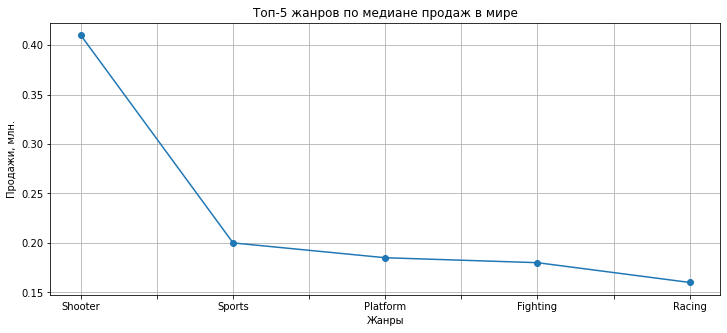

```python
# посмотрим медиану мировых продаж по платформам и выведем график зависимости на экран
data_tmp = data_actual_period.groupby('genre')['total_sales'].median()
display(data_tmp.sort_values(ascending=False))
data_tmp.sort_values(ascending=False).head().plot(style='o-', grid=True, figsize=(12, 5),
    title='Топ-5 жанров по медиане продаж в мире')
plt.xlabel('Жанры')
plt.ylabel('Продажи, млн.')
plt.show()
```

```
genre
Action          1287
Role-Playing     465
Adventure        410
Sports           389
Misc             382
Shooter          332
Racing           179
Fighting         159
Simulation       136
Platform         122
Strategy         118
Puzzle            71
Name: total_sales, dtype: int64
```

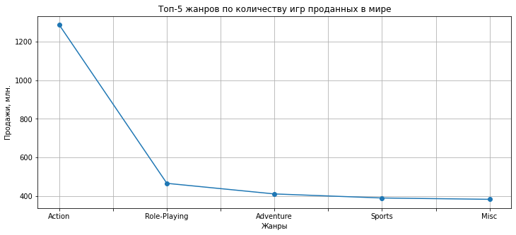

```python
# посмотрим количество мировых продаж по платформам и выведем график зависимости на экран
data_tmp2 = data_actual_period.groupby('genre')['total_sales'].count()
display(data_tmp2.sort_values(ascending=False))
data_tmp2.sort_values(ascending=False).head().plot(style='o-', grid=True, figsize=(12, 5),
    title='Топ-5 жанров по количеству игр проданных в мире')
plt.xlabel('Жанры')
plt.ylabel('Продажи, млн.')
plt.show()
```

```
genre
Action          565.22
Shooter         402.96
Role-Playing    245.63
Sports          237.39
Misc            139.91
Platform         88.68
Racing           88.23
Fighting         66.90
Simulation       50.26
Adventure        45.04
Strategy         22.51
Puzzle            9.85
Name: total_sales, dtype: float64
```

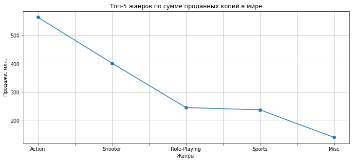

```python
# посмотрим медиану мировых продаж по платформам и выведем график зависимости на экран
data_tmp1 = data_actual_period.groupby('genre')['total_sales'].sum()
display(data_tmp1.sort_values(ascending=False))
data_tmp1.sort_values(ascending=False).head().plot(style='o-', grid=True, figsize=(12, 5),
    title='Топ-5 жанров по сумме проданных копий в мире')
plt.xlabel('Жанры')
plt.ylabel('Продажи, млн.')
plt.show()
```

#### Вывод:

Жанр, где игры стабильно приносят высокий доход - (медианные продажи) - это Шутеры.

Топ жанров с высокими доходами от продаж:

Action 565.22

Shooter 402.96

Sports 237.40

Misc 139.91

Топ жанров с низкими доходами:

Adventure 45.04

Puzzle 9.85

Топ жанров с высокой средней медианой продаж:

Shooter 0.410

Sports 0.200

Platform 0.185

Fighting 0.180

Racing 0.160

Puzzle 0.050

Adventure 0.030

Значит нужно больше закупать шутеры,  
далее спортивные игры, платформы, борьба и гонки - их чуть меньше  
меньше всего продаются приключения и паззлы (однако пазлы и стоят недорого)  
Игры в стиле Экшн быпускают больше поэтому суммарные их продажи выше шутеров.

### 4. Портрет пользователя каждого региона

К плану работ

### 4.1. Самые популярные платформы (топ-5)

К плану работ

| platform | eu_sales | jp_sales | na_sales |
| --- | --- | --- | --- |
| 3ds | 61.46 | 100.62 | 82.83 |
| ps3 | 164.14 | 49.40 | 168.96 |
| psp | 1.87 | 24.28 | 2.29 |
| psv | 13.07 | 21.84 | 12.47 |
| ps4 | 141.09 | 15.96 | 108.74 |
| wiiu | 25.13 | 13.01 | 38.10 |
| wii | 30.04 | 8.97 | 49.36 |
| ds | 9.50 | 8.04 | 19.33 |
| x360 | 117.87 | 3.36 | 228.18 |
| xone | 51.59 | 0.34 | 93.12 |
| ps2 | 0.13 | 0.09 | 0.13 |
| pc | 57.32 | 0.00 | 30.08 |

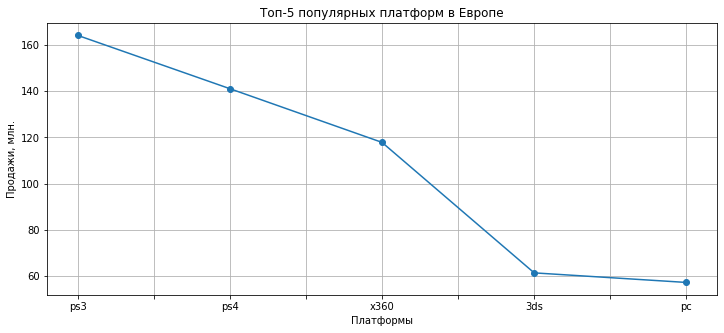

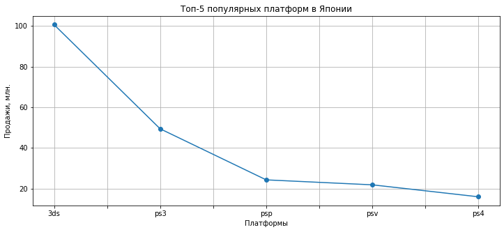

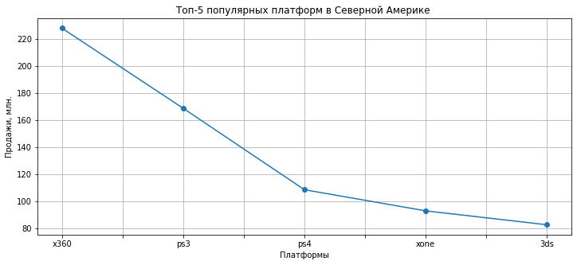

```python
# делаем сводную таблицу продаж по платформам по регионам
popular_platform = data_actual_period.pivot_table(index='platform', values=['na_sales', 'eu_sales', 'jp_sales'], aggfunc='sum')
display(popular_platform.sort_values(by='jp_sales', ascending=False))

# делаем сводную таблицу продаж по платформам в Еропе и график
popular_platform_eu = popular_platform.sort_values(by='eu_sales', ascending=False).head()
popular_platform_eu['eu_sales'].plot(style='o-', grid=True, figsize=(12, 5),
               title='Топ-5 популярных платформ в Европе')
plt.xlabel('Платформы')
plt.ylabel('Продажи, млн.')
plt.show()
# делаем сводную таблицу продаж по платформам в Японии и график
popular_platform_jp = popular_platform.sort_values(by='jp_sales', ascending=False).head()
popular_platform_jp['jp_sales'].plot(style='o-', grid=True, figsize=(12, 5),
               title='Топ-5 популярных платформ в Японии')
plt.xlabel('Платформы')
plt.ylabel('Продажи, млн.')
plt.show()
# делаем сводную таблицу продаж по платформам в США и график
popular_platform_na = popular_platform.sort_values(by='na_sales', ascending=False).head()
popular_platform_na['na_sales'].plot(style='o-', grid=True, figsize=(12, 5),
               title='Топ-5 популярных платформ в Северной Америке ')
plt.xlabel('Платформы')
plt.ylabel('Продажи, млн.')
plt.show()
```

#### Выводы:

В Европе самые поопулярные платформы:  
PS3 164.15  
PS4 141.09  
X360 117.87  
3DS 61.46  
PC 57.38  
В Северной Америке популярными платформами являются  
X360 228.18  
PS3 168.96  
PS4 108.74  
XOne 93.12  
3DS 82.83  
В Японии в топ-5 популярных платформ входит:  
3DS 100.62  
PS3 49.40  
PSP 24.28  
PSV 21.84  
PS4 15.96  
WiiU 13.01

Пользователи из Северной Америке и Европы очень похожи между собой, у них одинаковые предпочтения, за исключением только того, что в Америке XOne в топ 5 а в европе его пока нет. В европе в топ 5 поволи персональные компьютеры - не даром этот регион называют "Старушка Европа". Типовой японец любит все японское: nintendo, sony. Послединие их платформы только набирают продажи.

### 4.2. Самые популярные жанры (топ-5)

К плану работ

| genre | eu_sales | jp_sales | na_sales |
| --- | --- | --- | --- |
| Role-Playing | 0.010 | 0.06 | 0.010 |
| Fighting | 0.040 | 0.03 | 0.060 |
| Adventure | 0.000 | 0.02 | 0.000 |
| Action | 0.030 | 0.01 | 0.040 |
| Misc | 0.020 | 0.00 | 0.050 |
| Platform | 0.070 | 0.00 | 0.090 |
| Puzzle | 0.020 | 0.00 | 0.000 |
| Racing | 0.070 | 0.00 | 0.060 |
| Shooter | 0.150 | 0.00 | 0.180 |
| Simulation | 0.030 | 0.00 | 0.025 |
| Sports | 0.050 | 0.00 | 0.080 |
| Strategy | 0.015 | 0.00 | 0.000 |

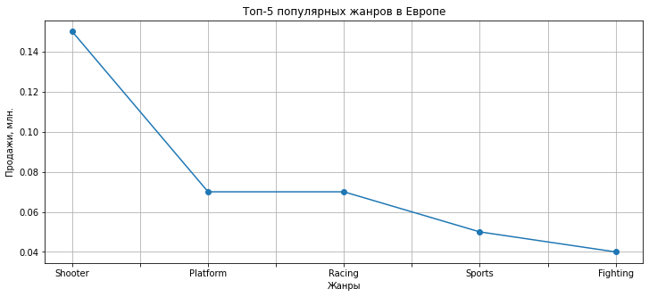

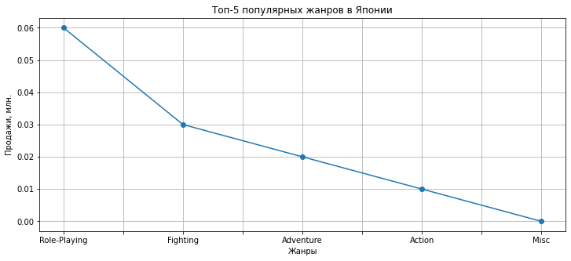

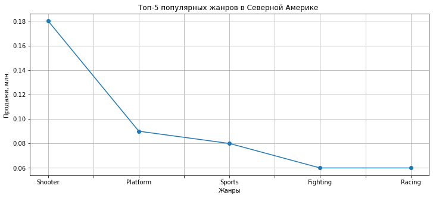

```python
popular_genre = data_actual_period.pivot_table(index='genre',
                    values=['na_sales', 'eu_sales', 'jp_sales'], aggfunc='median')
display(popular_genre.sort_values(by='jp_sales', ascending=False))

#графики
popular_genre_eu = popular_genre.sort_values(by='eu_sales', ascending=False).head()
popular_genre_eu['eu_sales'].plot(style='o-', grid=True, figsize=(12, 5),
               title='Топ-5 популярных жанров в Европе')
plt.xlabel('Жанры')
plt.ylabel('Продажи, млн.')
plt.show()

popular_genre_jp = popular_genre.sort_values(by='jp_sales', ascending=False).head()
popular_genre_jp['jp_sales'].plot(style='o-', grid=True, figsize=(12, 5),
               title='Топ-5 популярных жанров в Японии')
plt.xlabel('Жанры')
plt.ylabel('Продажи, млн.')
plt.show()

popular_genre_na = popular_genre.sort_values(by='na_sales', ascending=False).head()
popular_genre_na['na_sales'].plot(style='o-', grid=True, figsize=(12, 5),
               title='Топ-5 популярных жанров в Северной Америке ')
plt.xlabel('Жанры')
plt.ylabel('Продажи, млн.')
plt.show()
```

#### Вывод:

Топ-5 игровых жанров в Европе:

Shooter Platform  
Racing Sports  
Fighting

Топ-5 игровых жанров в Японии:

Role-Playing  
Fighting  
Adventure  
Action  
Misc

Как и с платформами пользователи европейцы и североамериканцы похожи между собой, в топ-5 одни и теже игровые жанры, отличие лишь в последовательности. Япония и тут выделяется. Fighting единственный жанр коротый совпадает. Role-Playing и Fighting лидируют. Скорее всего на выбор жанров влияет культура где карате и аниме накладывают отпечаток на популярность того или иного игрового жанра. Также может быть разница еще и в различии наиболее популярных платформ между Японией и Северной Америкой и Европой.

### 4.3. Влияет ли рейтинг ESRB на продажи в отдельном регионе?

К плану работ

| rating | eu_sales | jp_sales | na_sales |
| --- | --- | --- | --- |
| M | 251.40 | 26.15 | 309.32 |
| E | 141.92 | 36.68 | 170.25 |
| unknown | 116.67 | 138.46 | 124.03 |
| T | 83.31 | 33.39 | 109.62 |
| E10+ | 79.88 | 11.23 | 119.95 |
| RP | 0.03 | 0.00 | 0.00 |
| EC | 0.00 | 0.00 | 0.42 |

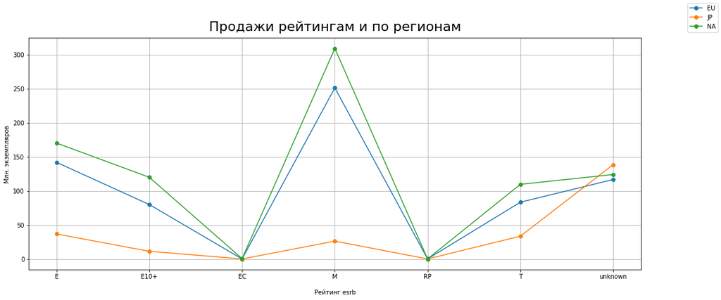

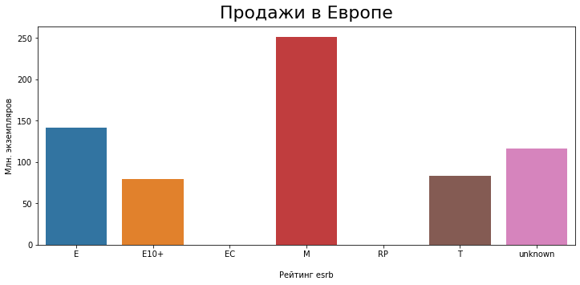

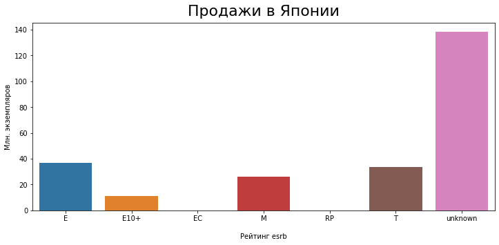

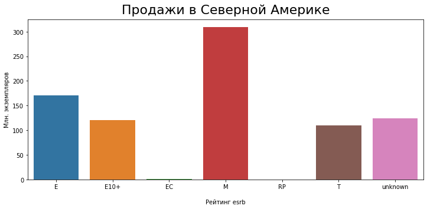

```python
# сводная таблица популярных рейтингов по регионам
popular_rating = data_actual_period.pivot_table(index='rating', values=['na_sales', 'eu_sales', 'jp_sales'], aggfunc='sum')
display(popular_rating.sort_values(by='eu_sales', ascending=False))

# график популярных рейтингов по регионам
fig, ax = plt.subplots(figsize=(18,7))
for elem in ['eu_sales', 'jp_sales', 'na_sales']:
    popular_rating[elem].plot(style='o-', grid=True)
fig.legend(labels=['EU', 'JP', 'NA'])
ax.set_title('Продажи рейтингам и по регионам', fontsize=22, y=1.015)
ax.set_xlabel('Рейтинг esrb', labelpad=16)
ax.set_ylabel('Млн. экземпляров')
plt.show()
# графики популярных рейтингов по регионам
list_area = {'eu_sales': 'Европе', 'jp_sales':'Японии', 'na_sales':'Северной Америке'}
for elem, name in list_area.items():
    fig, ax = plt.subplots(figsize=(12,5))
    sns.barplot(x=popular_rating.index, y=elem, data=popular_rating)
    ax.set_title('Продажи в ' + name, fontsize=22, y=1.015)
    ax.set_xlabel('Рейтинг esrb', labelpad=16)
    ax.set_ylabel('Млн. экземпляров')
    plt.show()
```

#### Вывод:

В Европе и Северной Америке опять совпадение по объему продаж изходя из рейтинга ESRB: ожидаемо на первом месте игры для взрослых (M), в аусайдерах игры от 10 (E10+) и 13(T) летнего возраста(дети ходят в школу и колледжи). Для Японии картина существенно другая: игры для всех категорий пользователей(E и Т) пользуются повышенным спросом, скорее всего из-за игр на основе аниме, например покемоны. Категория с неопределенным рейтингом игр самые большие продажи в Японии скорее всего связана с менее строгим законодательством в этой стране в части маркировки видеигр по сравнению с Северной Америкой и Европой. Разница в продажах между жанрами с разных концов топа в EU и NA для всех категрий пользователей одинакова и примерно отличается в 4 раза. В Японии игры без указания рейтинга занимают большую часть рынка. Рейтинг ESRB - это американский рейтинг, а в Японии есть своё рейтинговое агентство (CERO). Получается, что Япония страна со своим менталитетом. Анализ показывает, что Японцы в игры-то играют не такие, как весь прочий мир и жанры игр там популярны совсем другие, нежели в остальном мире, да и на рейтинги (не своего агентства) не очень то внимание обращают.

### 5.1. Гипотеза: средние пользовательские рейтинги платформ Xbox One и PC одинаковые

нулевая гипотеза H₀ средние пользовательские рейтинги платформ Xbox One и PC одинаковые

альтернативная гипотеза H₁ средние пользовательские рейтинги платформ Xbox One и PC не одинаковые

К плану работ

```python
# делаем срезы по платформам xone и pc
data_xone = data_actual_period.query('platform == "xone"').dropna(subset=['user_score'])
data_pc = data_actual_period.query('platform == "pc"').dropna(subset=['user_score'])

print('Дисперсия для платформ Xbox One:', np.var(data_xone['user_score']))
print('Дисперсия для платформ PC:', np.var(data_pc['user_score']))
alpha = 0.05 #критический уровень статистической значимости

results = st.ttest_ind(data_xone['user_score'], data_pc['user_score'],equal_var = False)

print('p-значение:', results.pvalue)

if (results.pvalue < alpha):
    print("Cредние пользовательские рейтинги платформ Xbox One и PC  разные")
else:
    print("Средние пользовательские рейтинги платформ Xbox One и PC одинаковые")
```

```
Дисперсия для платформ Xbox One: 1.8965188383045526
Дисперсия для платформ PC: 2.5627245353121904
p-значение: 0.6520920080002119
Средние пользовательские рейтинги платформ Xbox One и PC одинаковые
```

#### Вывод:

мы используем здесь двусторонний тест.

Проверка дисперсий выборок показала, что выборки различаются (отличатся более чем на 5%), следовательно equal_var = False. Средние пользовательские рейтинги платформ Xbox One и PC одинаковые.

### 5.2. Гипотеза: средние пользовательские рейтинги жанров Action (англ. «действие», экшен-игры) и Sports (англ. «спортивные соревнования») разные.

К плану работ

```python
# делаем срезы по жанрам Экшн и Спортс
data_Action = data_actual_period.query('genre == "Action"')
data_Action = data_Action.dropna(subset=['user_score'])

data_Sports = data_actual_period.query('genre == "Sports"')
data_Sports = data_Sports.dropna(subset=['user_score'])

data_xone.head()
# проеряем гипотезу
print('Дисперсия для жанра Action:', np.var(data_Action['user_score']))
print('Дисперсия для жанра Sports:', np.var(data_Sports['user_score']))
alpha = 0.05 #критический уровень статистической значимости

results = st.ttest_ind(data_Action['user_score'], data_Sports['user_score'],equal_var = False)

print('p-значение:', results.pvalue)

if (results.pvalue < alpha):
    print("Cредние пользовательские рейтинги жанров Action и Sports разные")
else:
    print("Средние пользовательские рейтинги жанров Action и Sports одинаковые")
```

```
Дисперсия для жанра Action: 1.7987170150891632
Дисперсия для жанра Sports: 2.8824163265306124
p-значение: 6.014476911203474e-19
Cредние пользовательские рейтинги жанров Action и Sports разные
```

Проверка дисперсий выборок показала, что выборки различаются (отличатся более чем на 5%), следовательно equal_var = False. Cредние пользовательские рейтинги жанров Action и Sports разные.

### 6. Общие тендениции продаж компьютерных игр в мире и по регионам

К плану работ

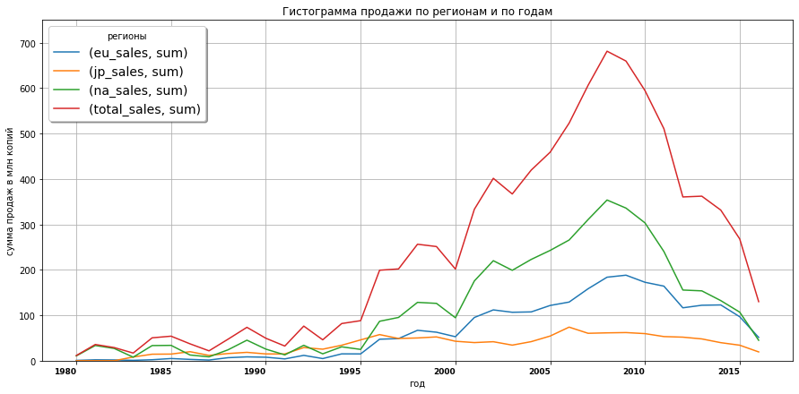

```python
data_total_sales = data2.pivot_table(index='year_of_release',
                                  values = ['total_sales', 'na_sales', 'eu_sales', 'jp_sales'],
                                     aggfunc={'sum'}).reset_index().plot(figsize=(15, 7), x='year_of_release')
plt.legend(fontsize=14, shadow=True,
           framealpha=1, title='регионы')
plt.xlabel('год')
plt.ylim(0,750)
plt.grid()
plt.ylabel('сумма продаж в млн копий')
plt.title('Гистограмма продажи по регионам и по годам')
plt.xticks(color='black', fontweight='bold', fontsize='9', horizontalalignment='right')
plt.show()
```

Мы видим общий тренд на затухание продаж компьютерных игр по платформам в 2016, и, скорее всего,в 2017 году этот тренд продолжится.  
Снижение продаж наблюдается и в мире вцелом, так и в каждом регионе в отдельности. Поэтому рекомендуется менять сферу деятельности интернет-магазина "Стримчик", например: на продажу онлайн игр для смартфонов и планшетов в том числе.  
Рассмотрим последние годы подробнее

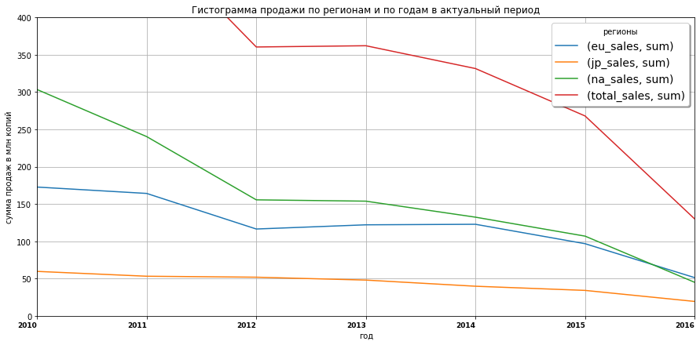

```python
data_total_sales = data2.pivot_table(index='year_of_release',
                                  values = ['total_sales', 'na_sales', 'eu_sales', 'jp_sales'],
                                     aggfunc={'sum'}).reset_index().plot(figsize=(15, 7), x='year_of_release')
plt.legend(fontsize=14, shadow=True,
           framealpha=1, title='регионы')
plt.xlabel('год')
plt.ylim(0,400)
plt.xlim(2010, 2016)
plt.grid()
plt.ylabel('сумма продаж в млн копий')
plt.title('Гистограмма продажи по регионам и по годам в актуальный период')
plt.xticks(color='black', fontweight='bold', fontsize='9', horizontalalignment='right')
plt.show()
```

### 7. Общий вывод

К плану работ

**В Европе и Америке** самые **популярные платформы** последнего и предоследнего поколения **компаний Sony и Microsoft** - **ps4 и ps3, и x360 и xone** соответственно - на этих платформах закупаем игры. **Жанры - шутеры и платформы**. Возрастная **категория +18 больше всего**, на втором месте **детские игры всех категорий включая подростковый возраст**.

Для **Японии** платформы родом из Японии **Sony и Nintendo 3ds и ps3**. Игры **Role-Playing и Fighting**. С категорией **для детей и тинэйджеров**, игры для взрослых там мало популярны, но **рейтинг ESRB там не действует**.

Высокий **рейтинг оценки экспертов не обязательно повлечет высокий уровень продаж**. При оценке экспертов **от 60 баллов** наблюдается **рост кол-ва игр с высоким количеством проданных копий**. Между продажами и отзывами отсутвует линейная взаимосвязь.

Высокий **рейтинг оценки пользователей не обязательно повлечет высокий уровень продаж**. При оценке пользователей **от 4-5 баллов наблюдается рост кол-ва игр с высоким кол-м проданных копий**. Между продажами и отзывами отсутвует линейная взаимосвязь.

Пользователи из Северной Америке и Европы очень похожи между собой, у них одинаковые предпочтения, за исключением только того, что в Америке более всего популярна X360. Типовой японец любит все японское: nintendo, sony.

Средние пользовательские рейтинги платформ Xbox One и PC одинаковые.  
Cредние пользовательские рейтинги жанров Action и Sports разные.  
Однако, **общий тренд на полное затухание продаж компьютерных игр на присутствующих в датасете платформах указывает на уход покупателей на другие рынки компьютерных игр - планшеты, смартфоны, онлайн-стриминговые платформы** и маркетинговому департаменту "Стримчика" надо ориентироваться в том числе и туда. **Ассортимент же компьютерных игр для консолей и персональных компьютеров должен быть распродан в ближайший год**.